# Modelo de Support Vector Machin & Redes neuronales

### TotalBsmtSF

Los datos están ligeramente normalizados.

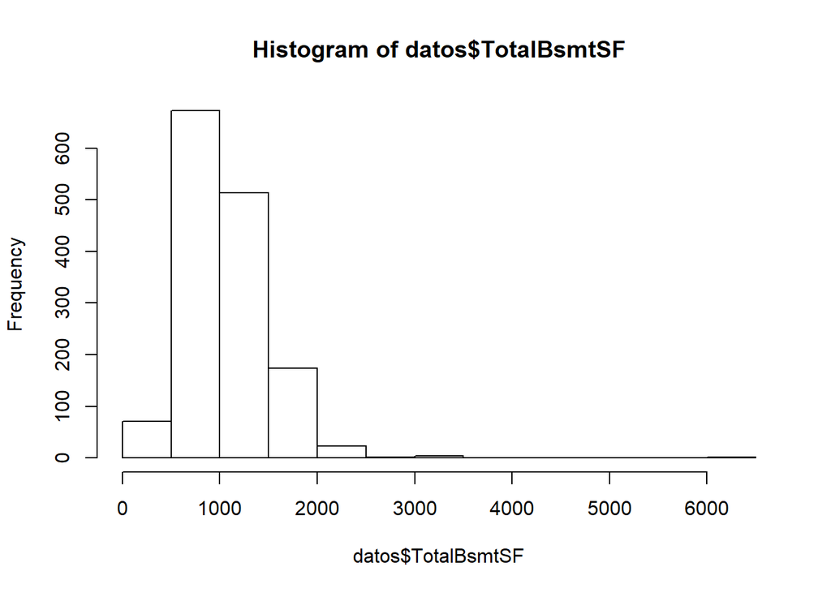

```r
hist(datos$TotalBsmtSF)
```

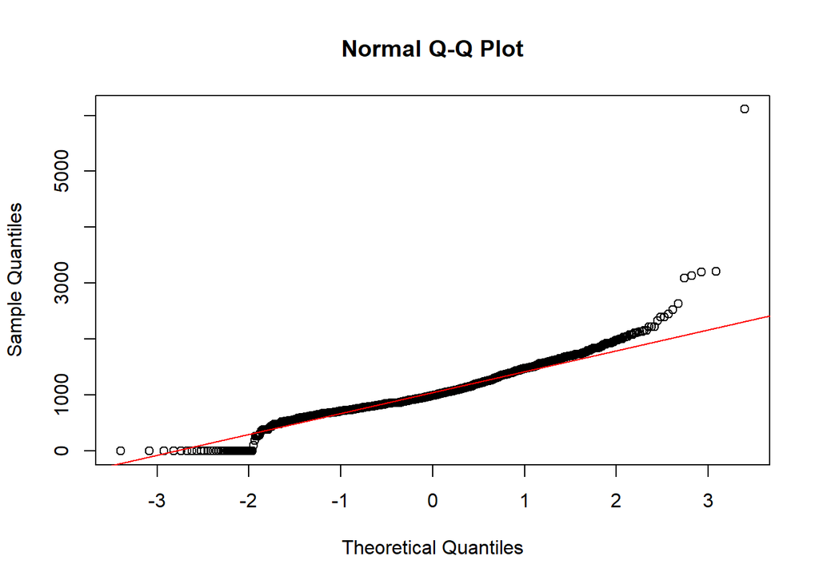

```r
qqnorm(datos$TotalBsmtSF)
qqline(datos$TotalBsmtSF, col='red')
```

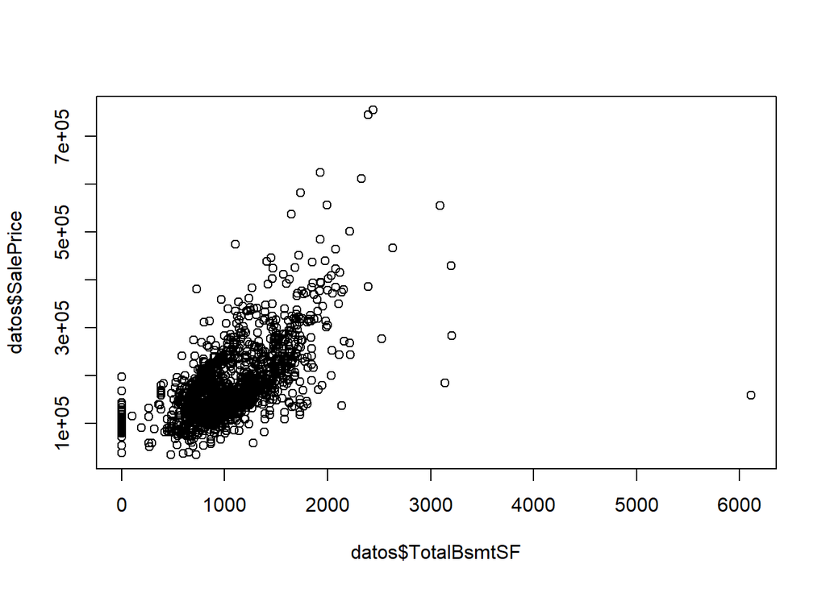

```r
plot(datos$TotalBsmtSF, datos$SalePrice)
```

### X1stFlrSF

Los datos están ligeramente normalizados.

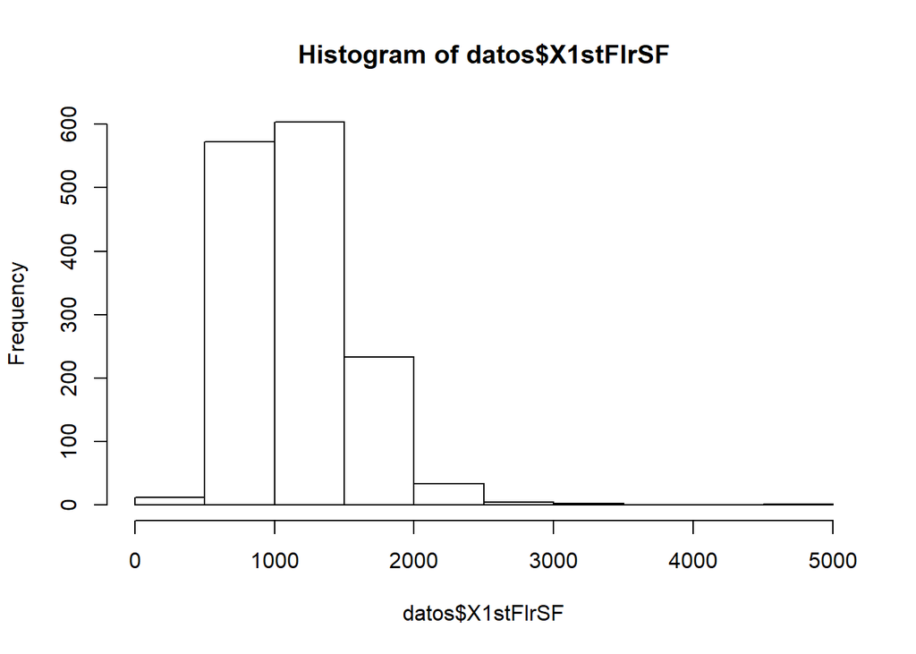

```r
hist(datos$X1stFlrSF)
```

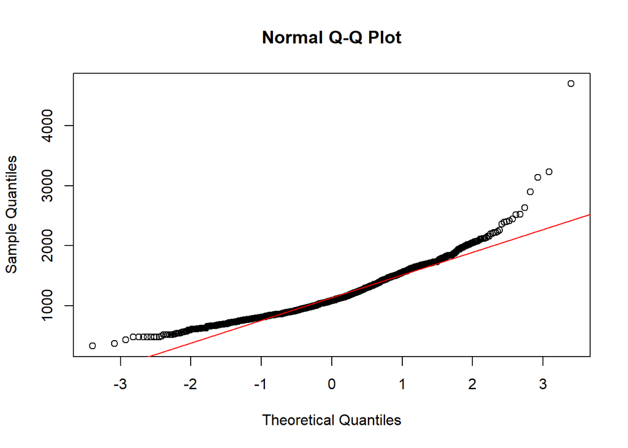

```r
qqnorm(datos$X1stFlrSF)
qqline(datos$X1stFlrSF, col='red')
```

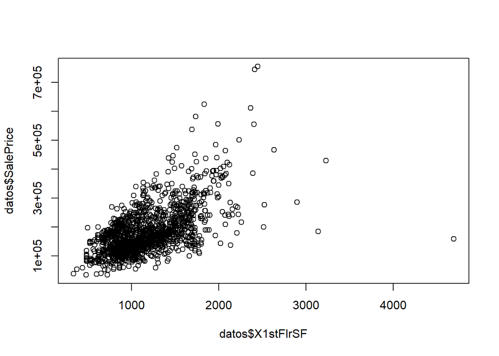

```r
plot(datos$X1stFlrSF, datos$SalePrice)
```

### GrLivArea

Los datos están ligeramente normalizados.

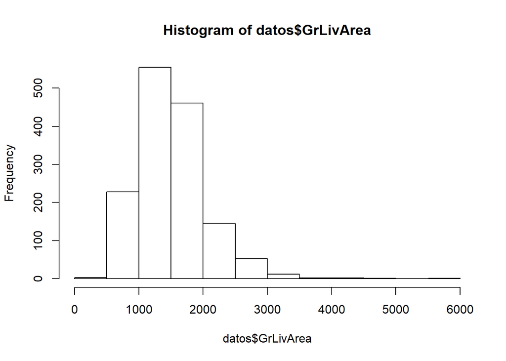

```r
hist(datos$GrLivArea)
```

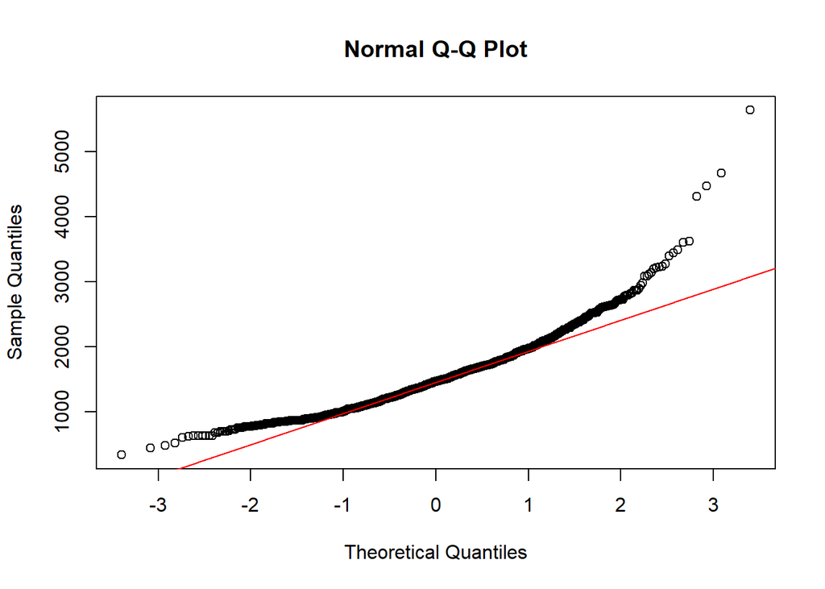

```r
qqnorm(datos$GrLivArea)
qqline(datos$GrLivArea, col='red')
```

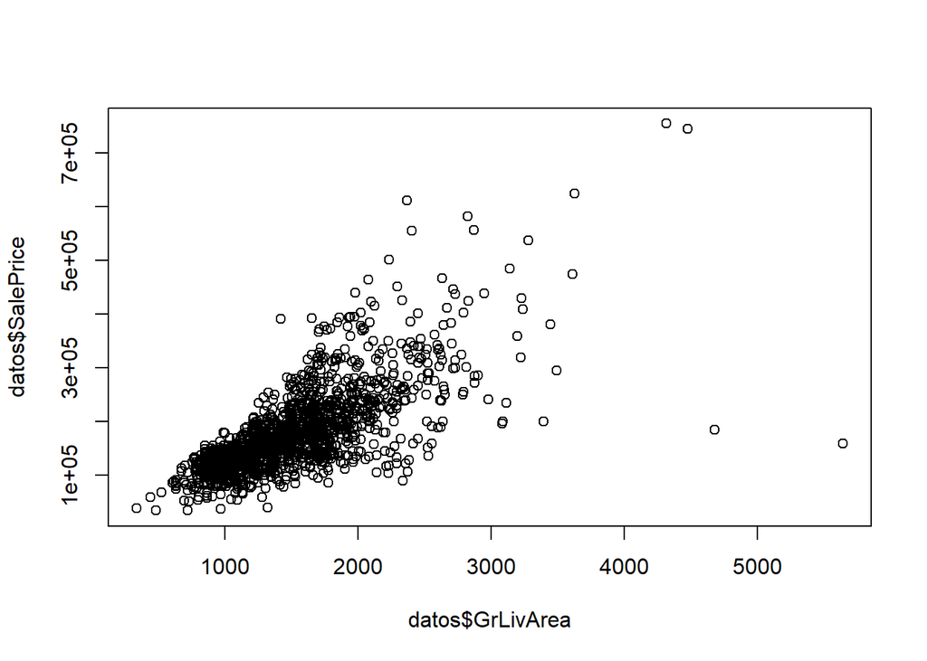

```r
plot(datos$GrLivArea, datos$SalePrice)
```

### GarageArea

Los datos están ligeramente normalizados.

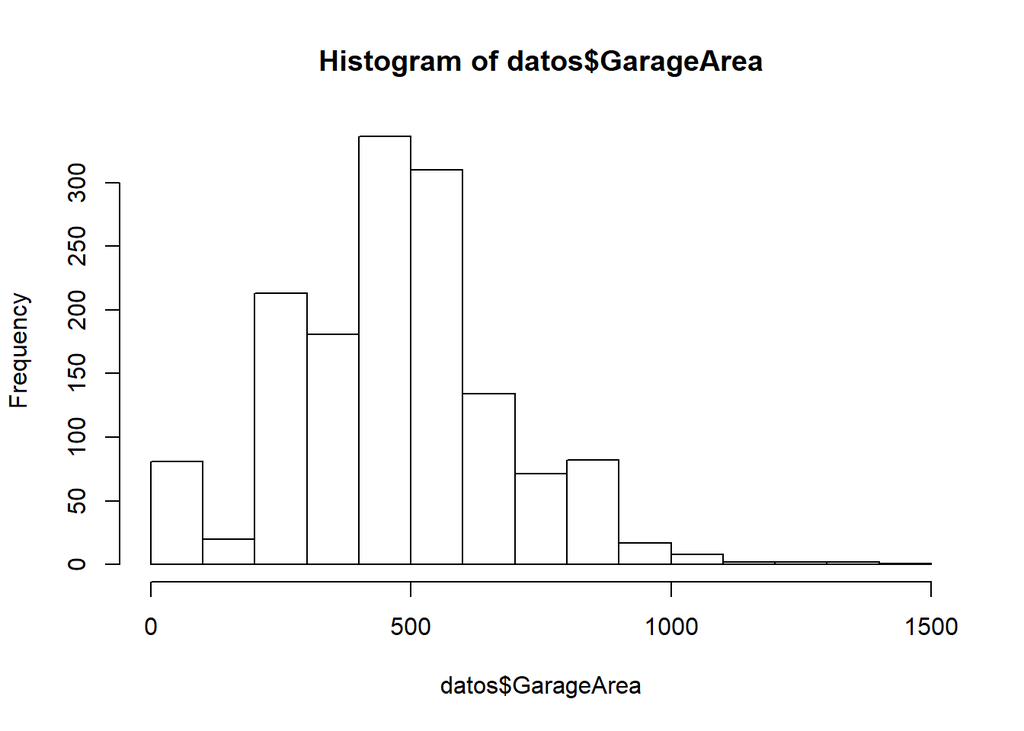

```r
hist(datos$GarageArea)
```

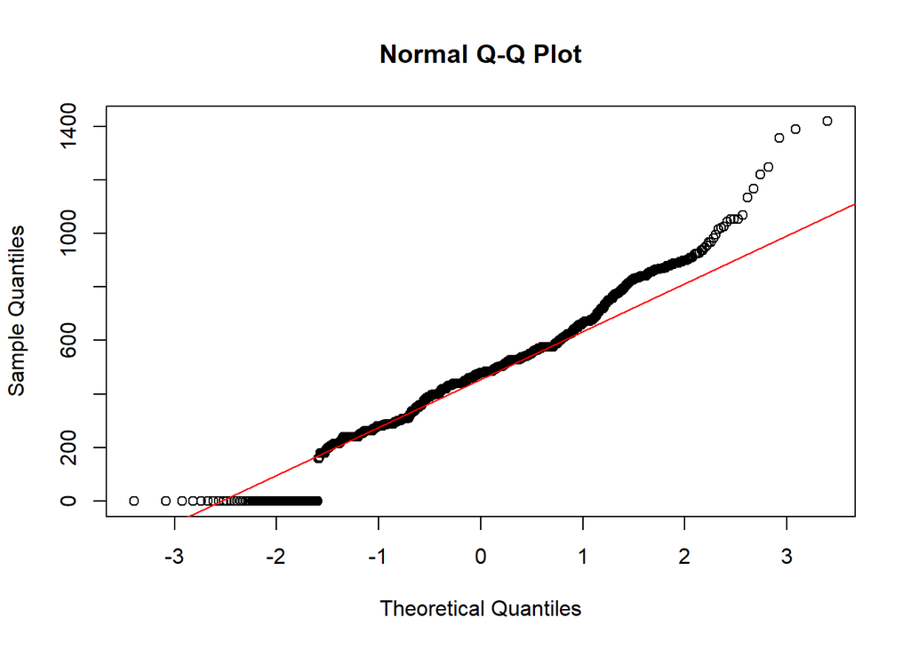

```r
qqnorm(datos$GarageArea)
qqline(datos$GarageArea, col='red')
```

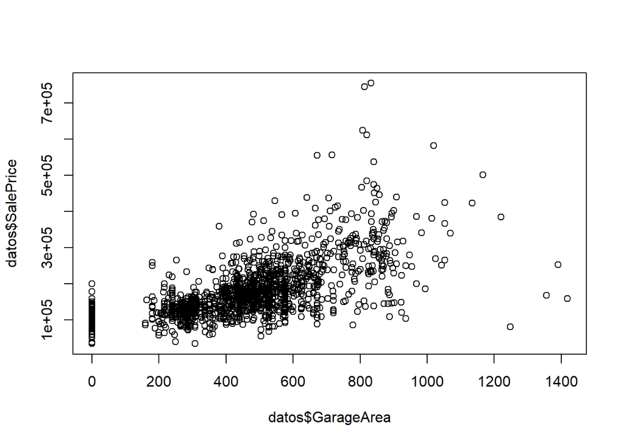

```r
plot(datos$GarageArea, datos$SalePrice)
```

### SalePrice

Los datos están ligeramente normalizados.

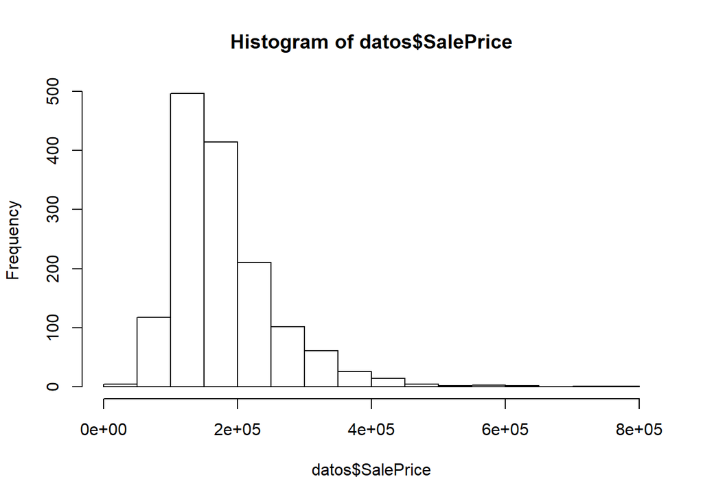

```r
hist(datos$SalePrice)
```

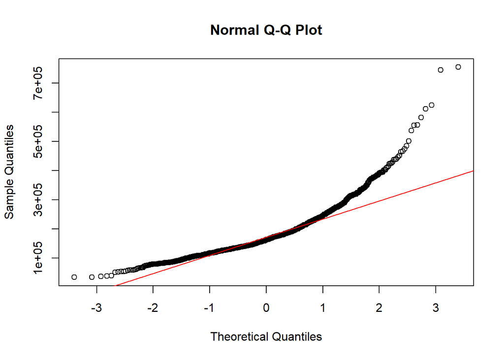

```r
qqnorm(datos$SalePrice)
qqline(datos$SalePrice, col='red')
```

Se procede con ejecutar el algoritmo de clústeres (3) para generar grupos de BARATO, INTERMEDIO y CARO

```r
cluster <- datos
km <- kmeans(datos, 3)
datos$grupo <- km$cluster


g1<- datos[datos$grupo==1,]
g2<- datos[datos$grupo==2,]
g3<- datos[datos$grupo==3,]
```

Y, se cambia el nombre del grupo de número a palabras, para una mejor comprensión y un mejor análisis posterior.

```r
if ((min(g1$SalePrice) > min(g2$SalePrice)) && (min(g1$SalePrice) > min(g3$SalePrice))) {
  if (min(g2$SalePrice) > min(g3$SalePrice)) {
    a <- c("Caro", "Intermedio", "Bajo")
  } else {
    a <- c("Caro", "Bajo", "Intermedio")
  }
} else if ((min(g1$SalePrice) < min(g2$SalePrice)) && (min(g1$SalePrice) < min(g3$SalePrice))) {
  if (min(g2$SalePrice) < min(g3$SalePrice)) {
    a <- c("Bajo", "Intermedio", "Caro")
  } else {
    a <- c("Bajo", "Caro", "Intermedio")
  }
} else {
  if (min(g2$SalePrice) < min(g3$SalePrice)) {
    a <- c("Intermedio", "Bajo", "Caro")
  } else {
    a <- c("Intermedio", "Caro", "Bajo")
  }
}

datos$grupo <- mapvalues(datos$grupo, c(1, 2, 3), a)
```

Para el análisis y comparación de los algoritmos contra Regresión Logística, necesitamos que la variable respuesta (grupo) sea dicotómica, así que se procede a converter la variable categórica en dicotómica, y se parte el dataset en TRAIN y TEST para entrenamiento y cross validation.

```r
porcentaje <- 0.7
datos <- cbind(datos, dummy(datos, verbose = T))
```

```
## 100 % of variables processed
```

```r
colnames(datos)[8:10] <- a

corte <- sample(nrow(datos), nrow(datos) * porcentaje)
train <- datos[corte, ]
test <- datos[-corte, ]

train$grupo <- as.factor(train$grupo)
test$grupo <- as.factor(test$grupo)
```

## Red Neuronal

### Con nnet (modelo 1)

```r
modelo <- nnet(grupo~., data = train[, c(1:5, 7)], size=5, rang=0.000001, decay=5e-4, maxit=500)
prediccion2 <- as.data.frame(predict(modelo, newdata = test[, 1:5]))
columnaMasAlta <- apply(prediccion2, 1, function(x) colnames(prediccion2)[which.max(x)])
test$prediccion2 <- columnaMasAlta

confusionMatrix(as.factor(test$prediccion2), as.factor(test$grupo))
```

```
## Confusion Matrix and Statistics
##
##             Reference
## Prediction   Bajo Caro Intermedio
##   Bajo        198    0         24
##   Caro          1   29         16
##   Intermedio   32    8        131
##
## Overall Statistics
##
##                Accuracy : 0.8155
##                  95% CI : (0.776, 0.8507)
##     No Information Rate : 0.5262
##     P-Value [Acc > NIR] : <2e-16
##
##                   Kappa : 0.6782
##
##  Mcnemar's Test P-Value : 0.1863
##
## Statistics by Class:
##
##                      Class: Bajo Class: Caro Class: Intermedio
## Sensitivity               0.8571     0.78378            0.7661
## Specificity               0.8846     0.95771            0.8507
## Pos Pred Value            0.8919     0.63043            0.7661
## Neg Pred Value            0.8479     0.97964            0.8507
## Prevalence                0.5262     0.08428            0.3895
## Detection Rate            0.4510     0.06606            0.2984
## Detection Prevalence      0.5057     0.10478            0.3895
## Balanced Accuracy         0.8709     0.87075            0.8084
```

### Con WEKA (modelo 2)

El modelo de redes neuronales con WEKA, se utiliza una capa oculta con 5 nodos en ella, se utilizaron 5000 iteraciones para obtener un bajo costo de la función.

```r
NB <- make_Weka_classifier("weka/classifiers/functions/MultilayerPerceptron")
nnodos='5'

modeloWeka <- NB(grupo~., data=train[, c(1:5, 7)], control=Weka_control(H=nnodos, N=5000, G=TRUE), options=NULL)
test$prediccionWeka <- predict(modeloWeka, newdata = test[, 1:5])
confusionMatrix(test$prediccionWeka, test$grupo)
```

```
## Confusion Matrix and Statistics
##
##             Reference
## Prediction   Bajo Caro Intermedio
##   Bajo        191    0         14
##   Caro          0   21         13
##   Intermedio   40   16        144
##
## Overall Statistics
##
##                Accuracy : 0.8109
##                  95% CI : (0.7711, 0.8465)
##     No Information Rate : 0.5262
##     P-Value [Acc > NIR] : < 2.2e-16
##
##                   Kappa : 0.6685
##
##  Mcnemar's Test P-Value : NA
##
## Statistics by Class:
##
##                      Class: Bajo Class: Caro Class: Intermedio
## Sensitivity               0.8268     0.56757            0.8421
## Specificity               0.9327     0.96766            0.7910
## Pos Pred Value            0.9317     0.61765            0.7200
## Neg Pred Value            0.8291     0.96049            0.8870
## Prevalence                0.5262     0.08428            0.3895
## Detection Rate            0.4351     0.04784            0.3280
## Detection Prevalence      0.4670     0.07745            0.4556
## Balanced Accuracy         0.8798     0.76761            0.8166
```

Los resultados son muy similares al modelo anterior. De igual forma, le cuesta predecir las caras que son caras, pues la sensitividad de las casas caras no alcanzó ni si quiera el 0.60. Se obtuvo un accuracy de 0.81.

Podemos notar que, aunque los modelos de redes neuronales son buenos modelos, para este caso, es preferible utilizar otros modelos pues, aciertan más y son más precisos.

## Regresión Logística

```r
num <- which(colnames(train) == "Bajo")
modelo <- glm(Bajo~., data = train[, c(1:5, num)], family = binomial(), maxit = 100)

pred <- predict(modelo, newdata = test[, 1:5], type = "response")
prediccion <- ifelse(pred >= 0.5, 1, 0)
confusionMatrix(as.factor(test$Bajo), as.factor(prediccion))
```

```
## Confusion Matrix and Statistics
##
##           Reference
## Prediction   0   1
##          0 393   9
##          1  15  22
##
##                Accuracy : 0.9453
##                  95% CI : (0.9197, 0.9647)
##     No Information Rate : 0.9294
##     P-Value [Acc > NIR] : 0.1101
##
##                   Kappa : 0.6177
##
##  Mcnemar's Test P-Value : 0.3074
##
##             Sensitivity : 0.9632
##             Specificity : 0.7097
##          Pos Pred Value : 0.9776
##          Neg Pred Value : 0.5946
##              Prevalence : 0.9294
##          Detection Rate : 0.8952
##    Detection Prevalence : 0.9157
##       Balanced Accuracy : 0.8365
##
##        'Positive' Class : 0
##
```

Ahora, vemos un gráfica (de dos dimensiones) de la regresión logística.

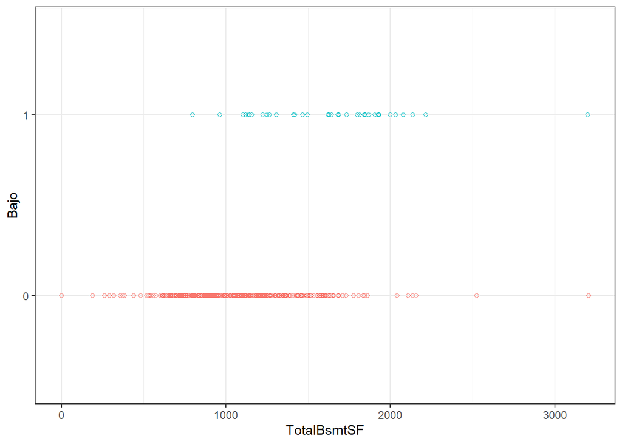

```r
ggplot(data = test, aes(x = TotalBsmtSF, y = Bajo)) +
  geom_point(aes(color = as.factor(Bajo)), shape = 1) +
  geom_smooth(method = "glm",
              method.args = list(family = "binomial"),
              color = "gray20",
              se = FALSE) +
  theme_bw() +
  theme(legend.position = "none")
```

## Naive Bayes

```r
nbTest = select(test, TotalBsmtSF, X1stFlrSF, GrLivArea, GarageCars, GarageArea, Bajo)
nbTrain = select(train, TotalBsmtSF, X1stFlrSF, GrLivArea, GarageCars, GarageArea, Bajo)

modelo <- naiveBayes(as.factor(nbTrain$Bajo)~., data=nbTrain)
predBayes <- predict(modelo, newdata = test[, 1:5])
confusionMatrix(as.factor(predBayes), as.factor(nbTest$Bajo))
```

```
## Confusion Matrix and Statistics
##
##           Reference
## Prediction   0   1
##          0 371   6
##          1  31  31
##
##                Accuracy : 0.9157
##                  95% CI : (0.8857, 0.94)
##     No Information Rate : 0.9157
##     P-Value [Acc > NIR] : 0.5436
##
##                   Kappa : 0.5822
##
##  Mcnemar's Test P-Value : 7.961e-05
##
##             Sensitivity : 0.9229
##             Specificity : 0.8378
##          Pos Pred Value : 0.9841
##          Neg Pred Value : 0.5000
##              Prevalence : 0.9157
##          Detection Rate : 0.8451
##    Detection Prevalence : 0.8588
##       Balanced Accuracy : 0.8804
##
##        'Positive' Class : 0
##
```

Vemos que el modelo de Naive Bayes obtiene un accuracy del 91.57%. También, la sensitividad y la especificidad son relativamente altas: 0.9229 y 0.8379 respectivamente. Están bien, pero hay mejores modelos.

## Regresión Lineal

```r
lTest = select(test, TotalBsmtSF, X1stFlrSF, GrLivArea, GarageCars, GarageArea, Bajo)
lTrain = select(train, TotalBsmtSF, X1stFlrSF, GrLivArea, GarageCars, GarageArea, Bajo)

modelo <-lm (Bajo~., data = lTrain)
predMLM <-predict(modelo, newdata = lTest[1:5])
prediccion <- ifelse(predMLM >= 0.5, 1, 0)
confusionMatrix(as.factor(prediccion), as.factor(lTest$Bajo))
```

```
## Confusion Matrix and Statistics
##
##           Reference
## Prediction   0   1
##          0   0   0
##          1 402  37
##
##                Accuracy : 0.0843
##                  95% CI : (0.06, 0.1143)
##     No Information Rate : 0.9157
##     P-Value [Acc > NIR] : 1
##
##                   Kappa : 0
##
##  Mcnemar's Test P-Value : <2e-16
##
##             Sensitivity : 0.00000
##             Specificity : 1.00000
##          Pos Pred Value :     NaN
##          Neg Pred Value : 0.08428
##              Prevalence : 0.91572
##          Detection Rate : 0.00000
##    Detection Prevalence : 0.00000
##       Balanced Accuracy : 0.50000
##
##        'Positive' Class : 0
##
```

## Árbol de clasificación

```r
ctTrain = select(train, TotalBsmtSF, X1stFlrSF, GrLivArea, GarageCars, GarageArea, Bajo)
ctTest = select(test, TotalBsmtSF, X1stFlrSF, GrLivArea, GarageCars, GarageArea, Bajo)
```

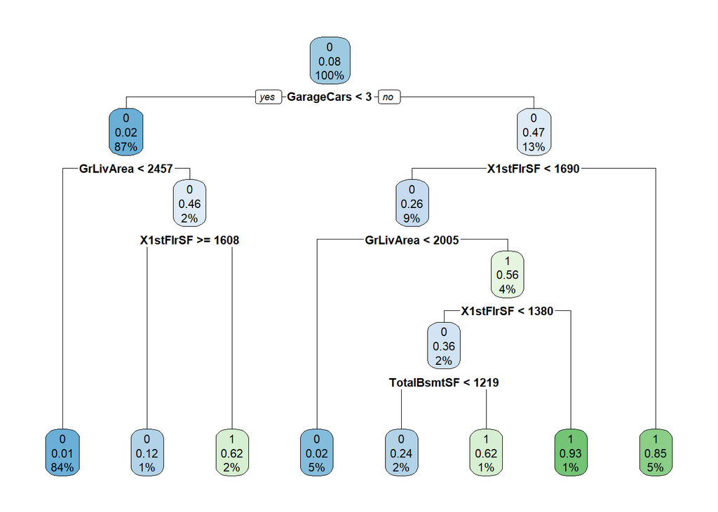

```r
dt_model<-rpart(ctTrain$Bajo~.,ctTrain,method = "class")
rpart.plot(dt_model)
```

```r
prediccion <- predict(dt_model, newdata = ctTest[1:5])
columnaMasAlta<-apply(prediccion, 1, function(x) colnames(prediccion)[which.max(x)])
ctTest$prediccion<-columnaMasAlta #Se le añade al grupo de prueba el valor de la predicción

cfm<-table(ctTest$Bajo,ctTest$prediccion)
confusionMatrix(table(ctTest$prediccion, ctTest$Bajo))
```

```
## Confusion Matrix and Statistics
##
##
##       0   1
##   0 387  16
##   1  15  21
##
##                Accuracy : 0.9294
##                  95% CI : (0.9013, 0.9515)
##     No Information Rate : 0.9157
##     P-Value [Acc > NIR] : 0.1729
##
##                   Kappa : 0.5368
##
##  Mcnemar's Test P-Value : 1.0000
##
##             Sensitivity : 0.9627
##             Specificity : 0.5676
##          Pos Pred Value : 0.9603
##          Neg Pred Value : 0.5833
##              Prevalence : 0.9157
##          Detection Rate : 0.8815
##    Detection Prevalence : 0.9180
##       Balanced Accuracy : 0.7651
##
##        'Positive' Class : 0
##
```

```r
cfm
```

```
##
##       0   1
##   0 387  15
##   1  16  21
```

El resultado del árbol de categorización es un accuracy del 0.9294. Con sensitividad y especificidad del 0.9627 y 0.5676. Como se mencionó anteriormente, es buen resultado, pero hay mejores.